# Distribución Espacial

Eduardo Chacón y Yanil Bravo

24 de agosto de 2017

# Distribución espacial

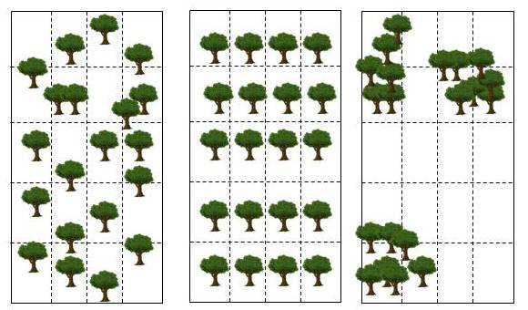

Fig. 1 Tipos de Distribución espacial, Aleatorio, Uniforme y Agregado

Para estudiar los patrones se utilizan los índices de dispersión.El índice de dispersión más sencillo de entender es la relación entre al variancia y el promedio.

$$\Large CD=\frac{s^2}{\bar{x}}$$

Supongamos que en cada una de las parcelas de la figura 1 hay 20 árboles y se hicieron 20 sub parcelas. El resultado final es que en cada una de las parcelas hay en promedio 1 individuo por sub parcela. Sin embargo, entre parcelas lo que cambia es la variancia, por ejemplo, en el primer caso, la variancia tiende a ser igual que el promedio, o sea en este caso el índice de dispersión es igual a 1. En el segundo caso la variancia tiende a 0, o sea en este caso el índice de dispersión es menor que 1. En el último caso, la variancia es muy alta porque hay sub parcelas sin árboles y otras con muchos, por lo tanto el índice de dispersión es mayor que 1.

### Usemos un ejemplo para entender el Indice de Disersión

```r
library(xlsx) # paquete se necesita para abrir archivos de Excel
library(vcd) # paquete opcional se necesita para comparar distribuciones de datos
```

# Primero abrimos los datos en Excel

```r
path<-c("C:/Users/Lalo/Dropbox/Cursos/Ecologia") # Escribir ruta donde están los archivos
setwd(path) # Establece "path" como ruta de trabajo
filename<-c("Datos_Palmas.xlsx")   # especifica nombre de archivo
datos<-data.frame(readxl::read_excel(filename, sheet = 1))
```

# Tabla de datos

```r
head(datos, 10) # Visualizar los primeros 10 datos
```

```
##    Asistente Parcela Sub_parcela Individuo N_tallos
## 1       Juan       1           1         1       13
## 2       Juan       1           1         2       18
## 3       Juan       1           1         3       14
## 4       Juan       1           1         4        3
## 5       Juan       1           1         5        7
## 6       Juan       1           1         6        1
## 7       Juan       1           1         7       12
## 8       Juan       1           1         8       14
## 9       Juan       1           1         9        8
## 10      Juan       1           2         1        2
```

# Exploremos los datos

En el conjunto de datos habían varios asistentes que hicieron varias parcelas y dentro de cada parcela varias subparcelas y dentro de estas contaron los individuos y el número de tallos por individuo. Primero queremos saber el número de individuos por parcela, para eso resumimos los datos de indiviudos por Asistente, parcela y sub_parcela. Como cada fila es un individuo, simplemente contamos el número de filas con la función *length*

```r
contar<-function(x) {length(which(x!=0))} # crea función para contar sin incluir cuando hay ceros
resumen<-aggregate(Individuo~Asistente+Parcela+Sub_parcela, data=datos, contar)
#La función aggregate es una de tantas que sive para reorganizar los datos o resumirlos.
# En este caso yo quiero resumirlos con la función *length* que lo que hace es contar. El comando cuenta el número de filas de Individuos resumidos por cada Asistente, Parcela y Sub_parcela diferente
```

```r
head(resumen, 10) # Visualizar los primeros 10 datos
```

```
##    Asistente Parcela Sub_parcela Individuo
## 1   Amandine       1           1         9
## 2      Diana       1           1        10
## 3       Juan       1           1         9
## 4      Karla       1           1        11
## 5      Marco       1           1         7
## 6      Nacho       1           1        12
## 7   Amandine       2           1         4
## 8      Diana       2           1         6
## 9       Juan       2           1        10
## 10     Karla       2           1         4
```

# Calculando el Indice de dispersión

Ahora teniendo del número de individuos por parcela calculamos el índice de dispersión

$$\Large CD=\frac{s^2}{\bar{x}}$$
Creamos la función para calcular el índice de dispersión usando la función de la variancia **var()** y la función del promedio **mean()**. Podemos especificar que no tome en cuenta las casillas en las que se perdieron datos por alguna razón, con el parámetro **na.rm=TRUE**

```r
CoefDisp<-function(x){var(x, na.rm=TRUE)/mean(x, na.rm=TRUE)}
CD<-CoefDisp(resumen$Individuo)
paste("Mi índice de dispersión es:", CD, sep="")
```

```
## [1] "Mi índice de dispersión es:2.34250658832678"
```

# ¿Es mi Indice de dispersión realmente diferente de uno?

Para saber eso usamos una prueba de chi cuadrado multiplicando el índice de dispersión por el número de grados de libertad que corresponde al número de parcelas menos uno

$$\chi{^2= CD(n-1)}$$

```r
# Crea la función para calcular el chi cuadrado del índice de dispersíón
ChiCD<-function(x){CoefDisp(x)*(length(x)-1)}

# Luego calculamos el chi
mi.chiCD<-ChiCD(resumen$Individuo)

# Calculamos los grados de libertad
mis.gl<-length(resumen$Individuo)-1

# Calculamos la probabilidad para el chi correspondiente
mi.p<-dchisq(x=mi.chiCD, df=mis.gl)


#Ponemos todo junto
paste("Mi Coeficiente de Dispersión es:", round(CD,3),
            "; Chi2 =", round(mi.chiCD,3),
            "; g.l.=", mis.gl, "; p=",
            round(mi.p,5), sep="")
```

```
## [1] "Mi Coeficiente de Dispersión es:2.343; Chi2 =185.058; g.l.=79; p=0"
```

```r
# NOTAS: la función round(), sirve para redondear
# La función paste() sirve para pegar objetos con texto
```

# Interpretación

La prueba indica que el coeficiente de dispersión es estadísticamente mayor a 1 y por lo tanto la distribución es agregada. Hay que tener cuidado que las pruebas de 2 X que generalmente se aplican son de una cola, puesto que casi siempre el interés es ver si el valor observado es diferente del esperado, no si es mayor o menor. Aquí el interés es una prueba de dos colas puesto que importa cuando el coeficiente de dispersión es mayor que uno, pero también la relación inversa. Como es una prueba de dos colas, para aceptar la hipótesis nula con una probabilidad alfa de 0.05, el valor de 2 X obtenido debe estar entre los valores de 2 X 0.975 y 2 X 0.025.

# Otras formas de comparar las distribuciónes

El índice de dispersión es fácil de calcular pero tiene muchas críticas. Es por eso que muchas veces es mejor probar si la distribución de nuestros datos sigue alguna distribución teórica, lo que nos permite hacer otras predicciones con los datos obtenidos. A continuación se describirán las tres distribuciones de probabilidad, de datos discretos, que más se utilizan para explicar datos que siguen los tres tipos básicos de dispersión que se pueden encontrar en los seres vivos. La distribución de Poisson que explica apropiadamente la dispersión aleatoria, la Binomial para datos de dispersión uniforme y la Binomial Negativa que explica muchas de las situaciones de dispersión

# Comprando con una ditstribución teórica de probabilidad

Para comparar con otras distribuciones teóricas primero debemos conocer algunos parámetros que describen la distribución de nuestros datos, como el promedio, la desviación estándar el tamaño de muestra, etc.

```r
promedio<-mean(resumen$Individuo) # calculo promedio
desvest<-sd(resumen$Individuo) # calculo desviación estándar
mi.var<-var(resumen$Individuo) # calculo variancia
mi.n<-length(resumen$Individuo) # calculo tamaño de muestra
mi.max<-max(resumen$Individuo) # número máximo de individuos por parcela
```

# También debo conocer la distribución de frecuencias de mis datos

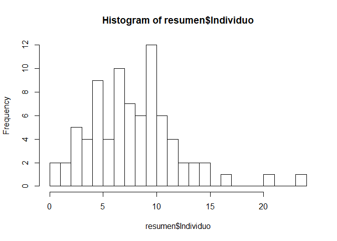

```r
a<-hist(resumen$Individuo, breaks=0:(mi.max+1), right=F, prob=FALSE) # crea un histograma
```

```r
str(a) # str se usa para ver la estructura de un objeto
```

```
## List of 6
##  $ breaks  : int [1:25] 0 1 2 3 4 5 6 7 8 9 ...
##  $ counts  : int [1:24] 2 2 5 4 9 4 10 7 6 12 ...
##  $ density : num [1:24] 0.025 0.025 0.0625 0.05 0.1125 ...
##  $ mids    : num [1:24] 0.5 1.5 2.5 3.5 4.5 5.5 6.5 7.5 8.5 9.5 ...
##  $ xname   : chr "resumen$Individuo"
##  $ equidist: logi TRUE
##  - attr(*, "class")= chr "histogram"
```

# para ver los conteos de frecuencias

```r
obs<-a$counts # el signo $ se usa para llamar un objeto de un tipo incluido dentro de otro objeto
obs<-append(obs, 0) # append siver para agregar elementos a un vector
# diferente a lo visto en clase agregue el cero después porque cambié la función del histograma que me cuenta la frecuencia de ceros
obs
```

```
##  [1]  2  2  5  4  9  4 10  7  6 12  6  4  2  2  2  0  1  0  0  0  1  0  0
## [24]  1  0
```

```r
q<-a$breaks # mis categorias
```

# Comparando con una distribución Poisson

Primero debo generar unos valores esperados

```r
p<-ppois(q,promedio) # calcula las probabilidades acumuladas para cada categoría "q" en una distribución con promedio "promedio" para una distribución poisson
p<-round(p, 4) # Redondea las probabilidades
p
```

```
##  [1] 0.0007 0.0055 0.0232 0.0663 0.1454 0.2611 0.4025 0.5504 0.6858 0.7961
## [11] 0.8768 0.9306 0.9634 0.9819 0.9916 0.9963 0.9985 0.9994 0.9998 0.9999
## [21] 1.0000 1.0000 1.0000 1.0000 1.0000
```

```r
p.esp<-append(p[1], diff(p)) # esta función sirve para calcular las probabilidades no acumuladas
p.esp
```

```
##  [1] 0.0007 0.0048 0.0177 0.0431 0.0791 0.1157 0.1414 0.1479 0.1354 0.1103
## [11] 0.0807 0.0538 0.0328 0.0185 0.0097 0.0047 0.0022 0.0009 0.0004 0.0001
## [21] 0.0001 0.0000 0.0000 0.0000 0.0000
```

```r
esp<-p.esp*mi.n #estima los valores esperados al multiplicar la probabilidad por el número total de parcelas
esp
```

```
##  [1]  0.056  0.384  1.416  3.448  6.328  9.256 11.312 11.832 10.832  8.824
## [11]  6.456  4.304  2.624  1.480  0.776  0.376  0.176  0.072  0.032  0.008
## [21]  0.008  0.000  0.000  0.000  0.000
```

# Graficando mis observados y esperados y comparándolos

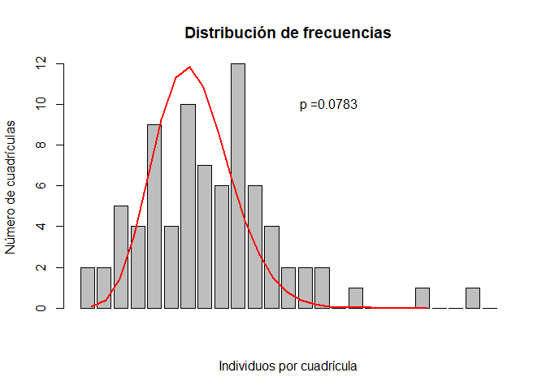

```r
# Gráfico de barras de los valores observados
barplot(obs, xlab="Individuos por cuadrícula",
     ylab="Número de cuadrículas",
     main="Distribución de frecuencias")
# Línea con los valores esperados
lines(esp, col="red", lwd=2)

# la prueba Kolomogorov-Smirnov sirve para hacer una prueba de bondad y ajuste entre dos distribuciones

ks.pois<-ks.test(x=cumsum(obs), y=cumsum(esp), alternative = "two.sided", exact=NULL)
# Agrego texto con la probabilidad de la prueba
text(18, 10, labels=paste("p =", round(ks.pois$p.value, 4), sep=""))
```

# Podemos hacer eso en un solo paso con una sola función del paquete **vcd**

La función **goodfit()** sirve para comparar la distribución de un conjunto de datos, directamente con una distribución teórica conicida

```r
pois.comp<-goodfit(resumen$Individuo, type="poisson", method=c("MinChisq"))
summary(pois.comp) # Devuelve el resultado de la comparación
```

```
##
##   Goodness-of-fit test for poisson distribution
##
##              X^2 df      P(> X^2)
## Pearson 715.8376 22 3.533464e-137
```

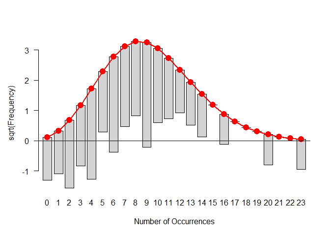

```r
plot(pois.comp) # Grafica el resultado
```

# Comparando con una binomial

La diferencia con la comparación en una binomial es que hay que conocer otros parámetros para calcular la distribución. Uno de los parámteros que se debería conocer o estimar es el número máximo de inividuos que puede aparecer en una parcela. Para eso se escoge el mayor entre el máximo observado o el máximo estimado y el máximo estimado se calcula con la función

$$\Large k=\frac{\bar{x}^2}{\bar{x}-s^2}$$
Y un estimador p que se calcula con k
$$\Large p=\frac{\bar{x}}{k}$$

```r
est.k<-ceiling(max(c(promedio^2/(promedio-mi.var), max(resumen$Individuo))))
#
est.p<-promedio/est.k
```

Estos parámetros se usan para calcular los esperados según una distribución binomial

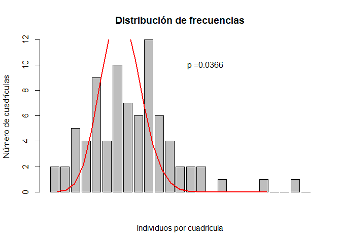

```r
p<-pbinom(q, est.k, est.p)
p<-round(p, 4)
p.esp<-append(p[1], diff(p))
esp<-p.esp*mi.n
barplot(obs, xlab="Individuos por cuadrícula",
        ylab="Número de cuadrículas",
        main="Distribución de frecuencias")
lines(esp, col="red", lwd=2)
ks.bn<-ks.test(x=cumsum(obs), y=cumsum(esp), alternative = "two.sided", exact=NULL)
text(18, 10, labels=paste("p =", round(ks.bn$p.value, 4), sep=""))
```

O usando el método con **goodfit**

```r
pois.comp<-goodfit(resumen$Individuo, type= "binomial")
summary(pois.comp)
```

```
##
##   Goodness-of-fit test for binomial distribution
##
##                       X^2 df     P(> X^2)
## Likelihood Ratio 130.5474 16 5.025072e-20
```

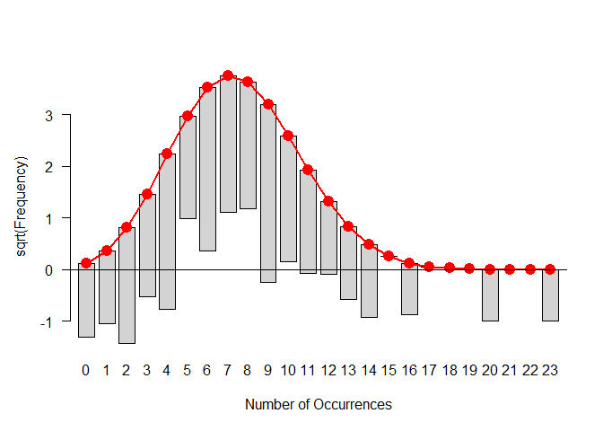

```r
plot(pois.comp)
```

# Comparando con una binomial negativa

Para comparar con una binomial negativa necesitamos otro estimador k diferente al de la binomial que se calcula con la siguiente fórmula:

$$\Large k=\frac{\bar{x}^2}{s^2-\bar{x}}$$

Luego es hacer lo mismo que con las anteriores

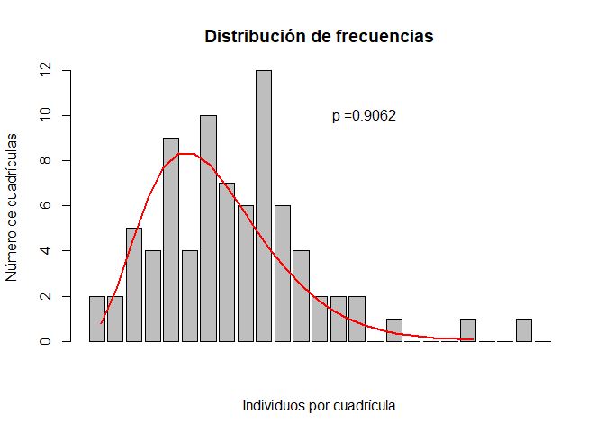

```r
est.k<-promedio^2/(mi.var-promedio)
p<-pnbinom(q, mu=promedio, size=est.k)
p<-round(p, 4)
p.esp<-append(p[1], diff(p))
esp<-p.esp*mi.n
barplot(obs, xlab="Individuos por cuadrícula",
        ylab="Número de cuadrículas",
        main="Distribución de frecuencias")
lines(esp, col="red", lwd=2)
ks.nbn<-ks.test(x=cumsum(obs), y=cumsum(esp), alternative = "two.sided", exact=NULL)
text(18, 10, labels=paste("p =", round(ks.nbn$p.value, 4), sep=""))
```

O usando el método con **goodfit**

```r
pois.comp<-goodfit(resumen$Individuo, type= "nbinomial")
summary(pois.comp)
```

```
##
##   Goodness-of-fit test for nbinomial distribution
##
##                      X^2 df   P(> X^2)
## Likelihood Ratio 22.7245 15 0.09016695
```

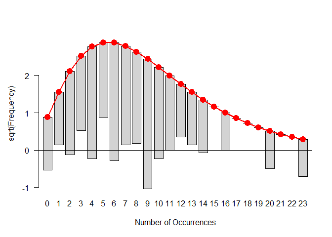

```r
plot(pois.comp)
```

Finalmente podemos comparar los resultados de las comparaciones concon las tres distribuciones

```r
row1<-c("Poisson", round(ks.pois$p.value,3), "Aleatoria")
row2<-c("Binomial", round(ks.bn$p.value,3), "Uniforme")
row3<-c("Binomial negativa", round(ks.nbn$p.value,3), "Agregado")


resultados<-data.frame(rbind(row1, row2, row3))
colnames(resultados)<-c("Ditr.teorica", "Prob", "Patron")
head(resultados, 4)
```

```
##           Ditr.teorica  Prob    Patron
## row1           Poisson 0.078 Aleatoria
## row2          Binomial 0.037  Uniforme
## row3 Binomial negativa 0.906  Agregado
```